# phage_play

## model 1

At first (“gwen”, sorry not very imaginative / correct) I tried to think about how you could have multiple equilibria. If I look at the ratio of teh final bacteria to phage its 10^-4 for 10^3, but 10^-2 for 10^4 / 10^5 right? as in 10^9 bacteria, and then they end up at 105 or 107. This gave me the (P/N - K) * (P/N-G) structure. So here I was thinking of model structure to give two equilibrium (set dp/dt = 0).

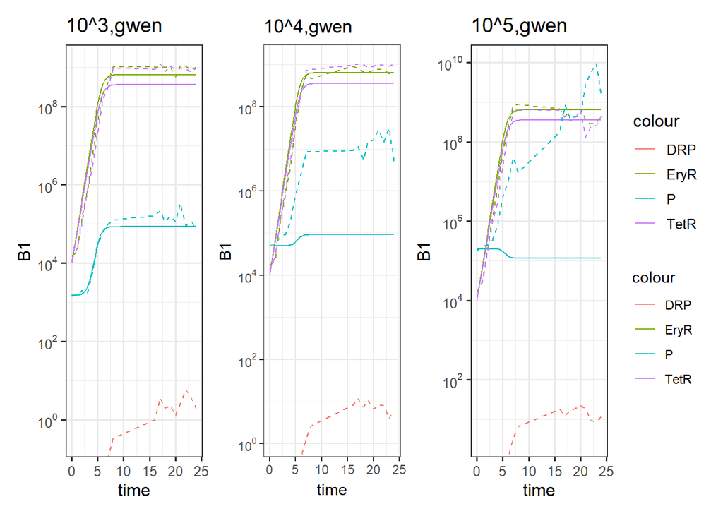

What’s interseting about this is that (1) is fits quite well the rapid growth which I know you weren’t getting with the other models (2) they all go to the 10^5 equilibrium. This is because, in the equations they go to the equilibrium closest to their starting value and here I only really played with K.

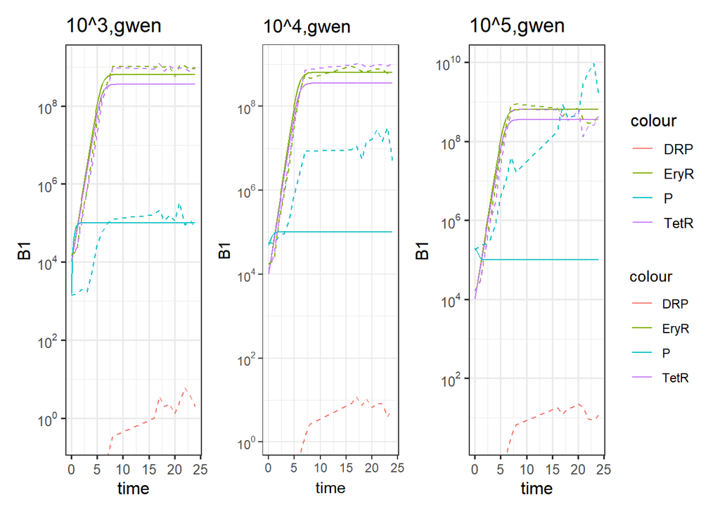

If I play with G, all hell goes on with the growth rate, but still end up at 10^5 equilbrium.

### Model 2

I wasn’t happy in gwen1 that there wasn’t a dependency on the final P equilibrium on N so added that into the bracket but can’t get this to look nicer….

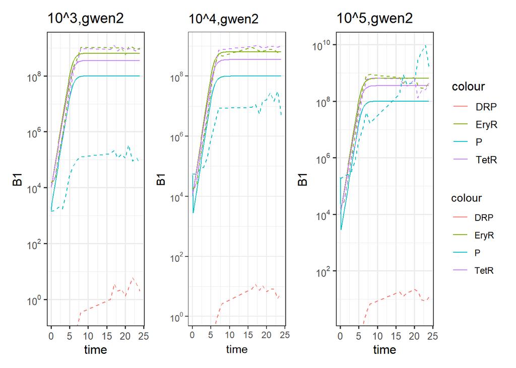

Now they all go to the higher equlibrium…